# Naive time series forecasting methods

Abstract

“Naive time series forecasting methods” published in R News.

### The Holt-Winters Method in package **ts**

Exponential smoothing methods forecast time series by discounted past observations. They have become very popular because of their (relative) simplicity compared to their good overall performance. Common applications range from business tasks (e.g., forecasting of sales or stock fluctuations) to environmental studies (e.g., measurements of atmospheric components or rainfall data)—with typically no more *a priori* knowledge than the possible existence of trend of seasonal patterns. Such methods are sometimes also called *naive* because no covariates are used in the models, i.e., the data are assumed to be self-explaining. Their success is rooted in the fact that they belong to a class of *local* models which automatically adapt their parameters to the data during the estimation procedure and therefore implicitly account for (slow) structural changes in the training data. Moreover, because the influence of new data is controlled by hyperparameters, the effect is a smoothing of the original time series.

Among the simplest methods is the ordinary exponential smoothing, which assumes no trend and no seasonality. Holt’s linear trend method (see Holt, 1957) and Winters extensions (see Winters, 1960) add a trend and a seasonal component (the latter either additive or multiplicative). Their methods are still surprisingly popular, although many extensions and more general frameworks do exist. We describe briefly the methods implemented in package **ts** and give some examples of their application.

#### Exponential smoothing

Let $Y_t$ denote a univariate time series. Exponential smoothing assumes that the forecast $\hat{Y}$ for period $t+h$ based on period $t$ is given by a variable level $\hat{a}$ at period $t$

$$\hat{Y}_{t+h} = \hat{a}_t \quad
(1)$$

which is recursively estimated by a weighted average of the observed and the predicted value for $Y_t$:

$$\begin{aligned} \hat{a}_t &= \alpha
Y_t + (1 - \alpha) \hat{Y}_t \\ &= \alpha Y_t + (1 - \alpha)
\hat{a}_{t-1} \end{aligned}$$

$0 < \alpha < 1$ called the smoothing parameter; the smaller it is chosen, the less sensitive $\hat{Y}$ becomes for changes (i.e., the smoother the forecast time series will be). The initial value $\hat{a}_1$ is usually chosen as $Y_1$.

An equivalent formulation for $\hat{a}_t$ is the so called error-correction form:

$$\begin{aligned} \hat{a}_t &=
\hat{a}_{t-1} + \alpha (Y_t - \hat{a}_{t-1}) \\ &= \hat{a}_{t-1} +
\alpha (Y_t - \hat{Y}_t) \\ &= \hat{a}_{t-1} + \alpha e_t
\end{aligned} \quad (2)$$

showing that $\hat{a}_t$ can be estimated by $\hat{a}_{t-1}$ plus an error $e$ made in period $t$. (We will come back to this later on.)

Exponential smoothing can be seen as a special case of the Holt-Winters method with no trend and no seasonal component. As an example, we use the

Nile data for which an intercept-only model seems appropriate[^1]. We will try to predict the values from 1937 on, choosing $\alpha = 0.2$:

```
library(ts)
data(Nile)
past <- window(Nile, end = 1936)
future <- window(Nile, start = 1937)
alpha <- 0.2
```

To obtain a level-only model, we set the other hyper-parameters $\beta$ and $\gamma$ (see the next sections) to 0:

```
model <- HoltWinters(past, alpha = alpha,
                     beta = 0, gamma = 0)
```

The object `model` contains an object of type “HoltWinters”. The fitted values (obtained by `fitted(model)`) should of course be identical[^2] to those given by `filter`:

```
filter(alpha * past, filter = 1 - alpha,
       method = "recursive", init = past[1])
```

```
pred <- predict(model, n.ahead = 43)
```

The `plot` method for Holt-Winters objects shows the observed and fitted values, and optionally adds the predicted values (see figure 1):

```
plot(model, predicted.values = pred)
lines(future)
```

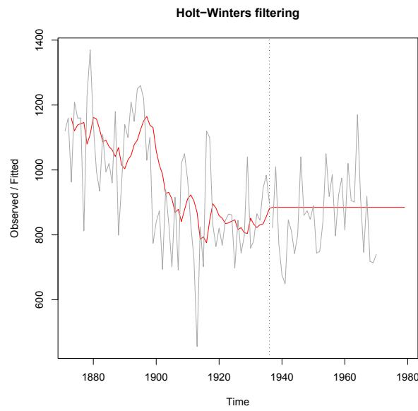

Figure 1: Exponential smoothing for the Nile data up to 1937, and the predictions in 1937 of the rest of the series. The original series is in shown in gray.

The coefficients (here only the level) are listed in the output produced by `print()` or can be extracted with `coef()`.

#### Holt’s linear trend method

An obvious extension is to include an additional trend component, say $\hat{b}_t$. The forecast equation becomes:

$$\hat{Y}_{t+h} = \hat{a}_t + h \cdot
\hat{b}_t$$

with updating formulas expressing similar ideas to those for exponential smoothing. There is an additional formula for the trend component:

$$\begin{aligned}\hat{a}_t &= \alpha
Y_t + (1 - \alpha)(\hat{a}_{t-1} + \hat{b}_{t-1}) \\ \hat{b}_t &=
\beta(\hat{a}_t - \hat{a}_{t-1}) + (1 -
\beta)\hat{b}_{t-1}\end{aligned}$$

The use is a *local* fit of a straight line with the coefficients adjusted for new values. We now have one more parameter to choose: $\beta$. A straightforward approach to find the optimal values for both $\alpha$ and $\beta$ is to look for the OLS estimates, i.e., the parameter combination minimizing the sum of squared errors of the one-step-ahead predictions. That is what `HoltWinters` does for all the unspecified parameters, illustrated below for the Australian residents data:

```
data(austres)
past <- window(austres, start = c(1985, 1),
               end = c(1989, 4))
future <- window(austres, start = c(1990, 1))
(model <- HoltWinters(past, gamma = 0))
```

Holt-Winters exponential smoothing with trend and without seasonal component.

```
Call:
HoltWinters(x = past, gamma = 0)
```

```
Smoothing parameters:
alpha: 0.931416
beta : 0.494141
gamma: 0
```

```
Coefficients:
[,1]
a 16956.68845
b 63.58486
```

The start values for $\hat{a}_t$ and $\hat{b}_t$ are $Y[2]$ and $Y[2] - Y[1]$, respectively; the parameters are estimated via `optim` using `method = "L-BFGS-B"`, restricting the parameters to the unit cube.

Another feature is the optional computation of confidence intervals for the predicted values, which by default are plotted along with them (see figure 2):

```
pred <- predict(model, n.ahead = 14,
                 prediction.interval = TRUE)
plot(model, pred); lines(future)
```

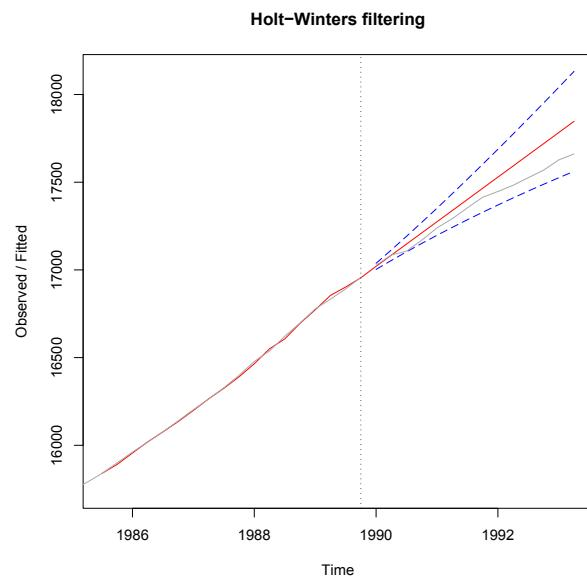

Figure 2: Holt’s linear trend method applied to data on Australian residents, with 95% confidence limits in dashed blue lines. Original data are plotted in gray, fitted and predicted values in red.

#### Winters’ seasonal method

Winters extended the method to include a seasonal component. There are additive and multiplicative versions. In the following, we suppose seasonal trend components $\hat{s}_t$ and a period $p$ (e.g., 4 for quarterly data).

##### Additive version

The additive model assumes the decomposition:

$$\hat{Y}_{t+h} = \hat{a}_t + h \cdot
\hat{b}_t + \hat{s}_t$$

with an additional updating formula for the seasonal component:

$$\begin{aligned}\hat{a}_t &=
\alpha(Y_t - \hat{s}_{t-p}) + (1 - \alpha)(\hat{a}_{t-1} +
\hat{b}_{t-1}) \\ \hat{b}_t &= \beta(\hat{a}_t - \hat{a}_{t-1}) + (1
- \beta)\hat{b}_{t-1} \\ \hat{s}_t &= \gamma(Y_t - \hat{a}_t) + (1 -
\gamma)\hat{s}_{t-p}\end{aligned}$$

#### Multiplicative version

This version assumes a model with time-increasing seasonal component (i.e., the amplitude becomes larger with increasing $t$). The prediction formula becomes:

$$\hat{Y}_{t+h} = (\hat{a}_t + h \cdot
\hat{b}_t) \hat{s}_t$$

For automatic parameter selection, we need at least three complete cycles to estimate an initial seasonal component, done via a classical seasonal decomposition using moving averages performed by the new function `decompose()`. The intercept and trend are estimated by a simple regression on the extracted trend component.

As an example, we apply the multiplicative version to the UK gas consumption data for 1960–80 and predict the next six years.

```
data(UKgas)
past <- window(UKgas, end = c(1980, 4))
future <- window(UKgas, start = c(1981, 1))
model <- HoltWinters(past, seasonal = "mult")
pred <- predict(model, n.ahead = 24)
```

For clarity, we plot the original time series and the predicted values separately (see figure 3):

```
par(mfrow = c(2,1))
plot(UKgas, main = "Original Time Series")
plot(model, pred)
```

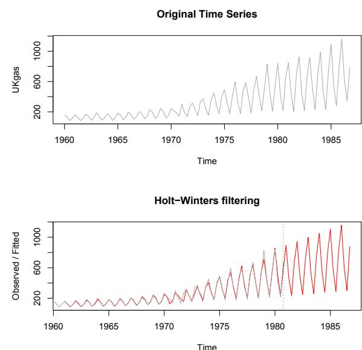

Figure 3: Winter’s method applied to quarterly UK gas consumption data. The upper figure is the actual data, the lower the data (gray) and fitted values (red) up to 1980Q4, the predictions (red) thereafter.

## Conclusion

We have seen that the Holt-Winters method consists in a simple yet effective forecasting procedure, based on exponential moving averages, covering both trend and seasonal models. Many extensions exist however (see, e.g., Hyndman et al., 2001), and the various formulations can also be seen as special cases of a wider class of models. For example, all but the multiplicative Holt-Winters can be identified as

(restricted) SARIMA models. To motivate this, consider equation 2—the error-correction form of exponential smoothing. By plugging it into the forecasting equation 1, we almost directly obtain:

$$\begin{aligned}(1 - L)\hat{Y}_t &=
\alpha e_{t-1} \\ &= (1 - \theta L)e_t\end{aligned}$$

($\theta = 1 - \alpha$), which is (in terms of estimates) the standard form of an ARIMA(0,1,1)-process. Finally, we note that we actually face *state-space* models: given process $Y_t$, we try to estimate the underlying processes $a_t$, $b_t$ and $s_t$ which cannot be observed directly. But this is the story of structural time series and the function `structTS`, told in an another article by Brian D. Ripley …

## References

- Holt, C. (1957). Forecasting seasonals and trends by exponentially weighted moving averages. *ONR Research Memorandum, Carnegie Institute* 52.
- Hyndman, R., Koehler, A., Snyder, R., & Grose, S. (2001). A state space framework for automatic forecasting using exponential smoothing methods. *Journal of Forecasting*. To appear.
- Winters, P. (1960). Forecasting sales by exponentially weighted moving averages. *Management Science*, 6, 324–342.
[^1]: At least piecewise: note that one might expect a structural break in 1899 due to the construction of the first Ashwan dam
[^2]: Currently the initial value is only observation 2 as it is for the trend model (for which this is sensible). This will be changed in R 1.5.1.